# CMSC320 FINAL PROJECT

## Metal Bands Around The World

##### Name: Yan-Jen Lo UID: 114204813 Due Date: 12/16/17 @ 1:30 PM

### INTERACTIVE MENU: \m/ ( -_- ) \m/

- **Introduction**
- **Goal**
- **Part I: Web Scrapping**
- **Part II: Data Analysis & Visualization**
- **Conclusion**
- **Sources**

[figure not shown]

# Introduction

### Inspiration: Kaggle's [Metal by Nation and Genre](https://www.kaggle.com/mrpantherson/metal-by-nation/data) Data

While looking around for a data set to use, I stumbled upon this kaggle entry on metal bands. Being a metal head since middle school, this peaked my interest like no other data set I've seen so far. After downloading the two data sets from [here](https://www.kaggle.com/mrpantherson/metal-by-nation/downloads/metal-bands-by-nation.zip):

1. **metal_bands_2017.csv**
2. **world_population_1960_2015.csv**

The dataset had only 5000 metal bands and the world population data didn't go up to 2017. Also if you check out this [kaggle notebook](https://www.kaggle.com/mrpantherson/metal-by-nation-and-genre/notebook), someone has already analyzed the data. I wanted to see for myself if the analysis for 5000 bands still holds for this data which is more than 20x larger.

### Data Sources: Encyclopedia Metallum & Wikipedia

| Data | Link | Stats | Date Accessed |
| --- | --- | --- | --- |
| **Encyclopedia Metallum** | [Metal-Archives](https://www.metal-archives.com) | 119474 Bands | 12/5/17 |
| **Wikipedia** | [Population Data](https://en.wikipedia.org/wiki/List_of_countries_and_dependencies_by_population) | 240 Countries | 12/15/17 |

When I use to look up bands, I used the **Encyclopedia Metallum** and the database had just about every obscure band you could find. Since they let users contribute to the databse (the acceptance process is heavily monitored), small bands can put themselves into the databse. Instead of using the kaggle data, I decided to scrape the metal archives myself since I felt that 5000 bands was lacking in terms of analysis for the entire world. For population data, I opted for **Wikipedia** since most of their population information was based on a real time [world population clock](http://worldpopulationclock.info).

[figure not shown]

### Goal: Analysis With Extensive Visualization (Graphs & Interactive World Map)

##### QUESTIONS:

1. **Which genre type seems to dominate the metal playing field?**
   - For the metal genre in general
   - For each country
   - Are most genres mixed or pure?
2. **Which country is the most metal?**
   - Most metal bands in proportion to population
   - Most still active metal bands in proportion to population
   - Most split-up metal bands in proportion to population

# PART I: Web Scrapping

- **Scrape All Countries**
- **HTTP Request**
- **BeautifulSoup**
- **Query All Countries With HTTP Request**
- **Execute Query Code & Write To TSV**
- **Load In Our TSV**
- **Scrape Population Data**
- **Wikipedia HTML**
- **Load In Population CSV**

## Scrap All Countries

[figure not shown]

```python
import time
from multiprocessing  import Pool
import requests
from bs4 import BeautifulSoup
import html5lib
import json

import pandas as pd
import numpy as np

import csv
import re
```

### HTTP Request

To scrap the countries page of **Encyclopedia Metallum**, we need to make a HTTP request to the URL. If the request was successful and a connection was created, the response should be:

```
<Response [200]>
```

```python
enyclopaedia_metallum_country_url = 'https://www.metal-archives.com/browse/country'
countries_request = requests.get(enyclopaedia_metallum_country_url)
print(countries_request)
```

```
<Response [200]>
```

### BeautifulSoup

To convert the request response into usable HTML tags easily, `BeautifulSoup` is the way to go. Make sure you have these imported:

```
from bs4 import BeautifulSoup
import html5lib
```

The `html5lib` library helps convert the response to HTML, thus allowing the use of `.find_all(tag)`. Your goal is to look at the HTML and figure which tags have the information you want and specifically target that tag to filter out as much as possible.

- In this case, the columns of countries starts with the tag:

```
<div class="countryCol">
```

##### Common .find_all Hacks

1) href or class field tag

```
<a href="https://www.metal-archives.com/lists/AF">Afghanistan"</a>
<div class="countryCol">
```

```
.find_all('a', href = True)
.find_all('div', class_ = True)
```

2) Specify field specifics with dictionaries

```
<div class="clear loading">
```

```
.find_all('a', {'class': 'clear loading'})
```

```python
soup = BeautifulSoup(countries_request.content, 'html5lib')
countries_soup = soup.find_all('div',{'class': 'countryCol'})
countries_soup
```

```
[<div class="countryCol">
 											<a href="https://www.metal-archives.com/lists/AF">Afghanistan</a><br/>
 											<a href="https://www.metal-archives.com/lists/AX">Åland Islands</a><br/>
 											<a href="https://www.metal-archives.com/lists/AL">Albania</a><br/>
 											<a href="https://www.metal-archives.com/lists/DZ">Algeria</a><br/>
 											<a href="https://www.metal-archives.com/lists/AD">Andorra</a><br/>
 											<a href="https://www.metal-archives.com/lists/AO">Angola</a><br/>
 											<a href="https://www.metal-archives.com/lists/AR">Argentina</a><br/>
 											<a href="https://www.metal-archives.com/lists/AM">Armenia</a><br/>
 											<a href="https://www.metal-archives.com/lists/AW">Aruba</a><br/>
 											<a href="https://www.metal-archives.com/lists/AU">Australia</a><br/>
 											<a href="https://www.metal-archives.com/lists/AT">Austria</a><br/>
 											<a href="https://www.metal-archives.com/lists/AZ">Azerbaijan</a><br/>
 											<a href="https://www.metal-archives.com/lists/BH">Bahrain</a><br/>
 											<a href="https://www.metal-archives.com/lists/BD">Bangladesh</a><br/>
 											<a href="https://www.metal-archives.com/lists/BB">Barbados</a><br/>
 											<a href="https://www.metal-archives.com/lists/BY">Belarus</a><br/>
 											<a href="https://www.metal-archives.com/lists/BE">Belgium</a><br/>
 											<a href="https://www.metal-archives.com/lists/BZ">Belize</a><br/>
 											<a href="https://www.metal-archives.com/lists/BO">Bolivia</a><br/>
 											<a href="https://www.metal-archives.com/lists/BA">Bosnia and Herzegovina</a><br/>
 											<a href="https://www.metal-archives.com/lists/BW">Botswana</a><br/>
 											<a href="https://www.metal-archives.com/lists/BR">Brazil</a><br/>
 											<a href="https://www.metal-archives.com/lists/BN">Brunei</a><br/>
 											<a href="https://www.metal-archives.com/lists/BG">Bulgaria</a><br/>
 											<a href="https://www.metal-archives.com/lists/KH">Cambodia</a><br/>
 											<a href="https://www.metal-archives.com/lists/CA">Canada</a><br/>
 											<a href="https://www.metal-archives.com/lists/CL">Chile</a><br/>
 											<a href="https://www.metal-archives.com/lists/CN">China</a><br/>
 											<a href="https://www.metal-archives.com/lists/CO">Colombia</a><br/>
 											<a href="https://www.metal-archives.com/lists/CR">Costa Rica</a><br/>
 											<a href="https://www.metal-archives.com/lists/HR">Croatia</a><br/>
 											<a href="https://www.metal-archives.com/lists/CU">Cuba</a><br/>
 											<a href="https://www.metal-archives.com/lists/CW">Curaçao</a><br/>
 											<a href="https://www.metal-archives.com/lists/CY">Cyprus</a><br/>
 											<a href="https://www.metal-archives.com/lists/CZ">Czech Republic</a><br/>
 											<a href="https://www.metal-archives.com/lists/DK">Denmark</a><br/>
 											<a href="https://www.metal-archives.com/lists/DO">Dominican Republic</a><br/>
 											<a href="https://www.metal-archives.com/lists/EC">Ecuador</a><br/>
 											<a href="https://www.metal-archives.com/lists/EG">Egypt</a><br/>
```

[output cut: 97 more lines]

```
 											<a href="https://www.metal-archives.com/lists/TT">Trinidad and Tobago</a><br/>
 											<a href="https://www.metal-archives.com/lists/TN">Tunisia</a><br/>
 											<a href="https://www.metal-archives.com/lists/TR">Turkey</a><br/>
 											<a href="https://www.metal-archives.com/lists/TM">Turkmenistan</a><br/>
 											<a href="https://www.metal-archives.com/lists/UG">Uganda</a><br/>
 											<a href="https://www.metal-archives.com/lists/UA">Ukraine</a><br/>
 											<a href="https://www.metal-archives.com/lists/AE">United Arab Emirates</a><br/>
 											<a href="https://www.metal-archives.com/lists/GB">United Kingdom</a><br/>
 											<a href="https://www.metal-archives.com/lists/US">United States</a><br/>
 											<a href="https://www.metal-archives.com/lists/ZZ">Unknown</a><br/>
 											<a href="https://www.metal-archives.com/lists/UY">Uruguay</a><br/>
 											<a href="https://www.metal-archives.com/lists/UZ">Uzbekistan</a><br/>
 											<a href="https://www.metal-archives.com/lists/VE">Venezuela</a><br/>
 											<a href="https://www.metal-archives.com/lists/VN">Vietnam</a><br/>
 									</div>]
```

As you can see from above, all the countries are in this tag format:

```
<a href="https://www.metal-archives.com/lists/(COUNTRY ID)">(COUNTRY)</a>
```

I simply extracted the countries out by looping through every country tag and using a regular expression's (regex) `.groups()` capabilities. Don't forget to import the regex library before use. Regexes are pretty useful, take a look [here](https://docs.python.org/3.4/library/re.html) for official documentation.

```
import re
re.compile('<a href="https://www.metal-archives.com\/lists\/(.+)">(.+)</a>')
```

With the parenthesis around the parts where I want to extract information, `.groups()` will return a tuple in the form of `(COUNTRY ID, COUNTRY)`.

```python
# Create country dictionary where country is the key and the country id is the value
all_countries = {}
country_regex = re.compile('<a href="https://www.metal-archives.com\/lists\/(.+)">(.+)</a>')

for col in range(len(countries_soup)):
    country_a_href = countries_soup[col].find_all('a') # Further filtering tags to only country tags
    for a_href in range(len(country_a_href)):
        tag = str(country_a_href[a_href]).strip()
        matched = country_regex.match(tag).groups() # (ID, country)
        all_countries[matched[0]] = (matched[1])

all_countries
```

```
{'AD': 'Andorra',
 'AE': 'United Arab Emirates',
 'AF': 'Afghanistan',
 'AL': 'Albania',
 'AM': 'Armenia',
 'AO': 'Angola',
 'AR': 'Argentina',
 'AT': 'Austria',
 'AU': 'Australia',
 'AW': 'Aruba',
 'AX': 'Åland Islands',
 'AZ': 'Azerbaijan',
 'BA': 'Bosnia and Herzegovina',
 'BB': 'Barbados',
 'BD': 'Bangladesh',
 'BE': 'Belgium',
 'BG': 'Bulgaria',
 'BH': 'Bahrain',
 'BN': 'Brunei',
 'BO': 'Bolivia',
 'BR': 'Brazil',
 'BW': 'Botswana',
 'BY': 'Belarus',
 'BZ': 'Belize',
 'CA': 'Canada',
 'CH': 'Switzerland',
 'CL': 'Chile',
 'CN': 'China',
 'CO': 'Colombia',
 'CR': 'Costa Rica',
 'CU': 'Cuba',
 'CW': 'Curaçao',
 'CY': 'Cyprus',
 'CZ': 'Czech Republic',
 'DE': 'Germany',
 'DK': 'Denmark',
 'DO': 'Dominican Republic',
 'DZ': 'Algeria',
 'EC': 'Ecuador',
 'EE': 'Estonia',
```

[output cut: 93 more lines]

```
 'TM': 'Turkmenistan',
 'TN': 'Tunisia',
 'TR': 'Turkey',
 'TT': 'Trinidad and Tobago',
 'TW': 'Taiwan',
 'UA': 'Ukraine',
 'UG': 'Uganda',
 'US': 'United States',
 'UY': 'Uruguay',
 'UZ': 'Uzbekistan',
 'VE': 'Venezuela',
 'VN': 'Vietnam',
 'XX': 'International',
 'ZA': 'South Africa',
 'ZZ': 'Unknown'}
```

### Query All Countries With HTTP Request

This part is somewhat complex because of the way the **Encyclopedia Metallum** is made. When you click on a country, you will see all the bands for that specific country.

[figure not shown]

#### Here are the 3 main difficulties with scraping this part of the database:

1. If you try to `BeautifulSoup` the HTML code, you won't see any of the listed bands because the webpage is a `JavaScript` rendered webpage. As you can see with the inspect element I captured through **Internet Explorer (IE)**.
2. If the country has more than 500 bands total, they are displayed by page number in batches of 500.
3. If you try to scrap the same website a lot, most websites can detect it, and thus disconnect your HTTP connection.

[figure not shown]

#### Sources Used:

1) Source for deriving solutions to #1 and #2: [jonchar](https://github.com/jonchar/ma-scraper) on **GitHub** wrote his own [scraper](https://github.com/jonchar/ma-scraper/blob/master/MA_band_scraper.py) for the **Encyclopedia Metallum**.

2) Solution to number #3 was from this [Stack Overflow post](https://stackoverflow.com/questions/27652543/how-to-use-python-requests-to-fake-a-browser-visit) and links to HTTP headers are [here](http://www.useragentstring.com/pages/useragentstring.php).

#### Solution to Problem #1: AJAX Call With HTTP Requests

You can see the `JavaScript` command to the **AJAX Databse** (this is where all their data on bands is stored). To specify which country you want to see, you simply put in the country's ID number, which we have extracted earlier.

```
var grid = createGrid("#bandListCountry", 500, 'browse/ajax-country/c/(COUNTRY ID)/json/1/', {aoColumns: [ null, null, null, { bSortable: false, sWidth: '80px'} ] });
```

Instead of doing an HTTP Request like usual, we have to add the **AJAX** call to the end of the URL. The **AJAX database** doesn't return HTML, it gives you data in **JSON** form, so essentially `Python` dictionary form. Make sure you have the **JSON** library imported.

```
import json
```

#### Solution to Problem #2: Parameters & Payload With HTTP Requests

When a country has more than 500 bands, there will be more than one page, therefore we use the `params` part of HTTP requests and give it a payload. Look at jonchar's README.md for detail explanation of payload. Basically, to get the first page, you want:

```
payload = {'sEcho': 0, 'iDisplayStart': 0, 'iDisplayLength': 500}
```

For every consecutive page, you increase both start and end by 500. You want to do this until you've reached the last page.

#### Solution to Problem #3: Headers & User-Agents With HTTP Requests

Since we are querying one country (there's around 140 countries listed) at a time and each page at a time, we'll make maybe close to 200 requests to **Encyclopedia Metallum**. To prevent the website from disconnecting our HTTP request, we have to pretend to be browser accessing the page. The best way is to give the request a **User-Agent** along with the request. With the header below, I'm pretending to be **Firefox**:

```
headers = {'User-Agent': 'Mozilla/5.0 (Windows NT 6.1; WOW64; rv:40.0) Gecko/20100101 Firefox/40.1'}
```

```python
# Helper function that returns all the bands listed for
# a specific country and the specific page requested
def get_page_query(country, CID, start, end):

    # Full AJAX database call components
    URL = 'http://www.metal-archives.com'
    AJAX_REQUEST_BEGIN = '/browse/ajax-country/c/'
    AJAX_REQUEST_END = '/json/1/'

    payload = {'sEcho': 0,
                'iDisplayStart': start,
                'iDisplayLength': end}
    headers = {'User-Agent': 'Mozilla/5.0 (Windows NT 6.1; WOW64; rv:40.0) Gecko/20100101 Firefox/40.1'}

    # Request with payload and headers
    r = requests.get(URL + AJAX_REQUEST_BEGIN + CID + AJAX_REQUEST_END,
                     params = payload,
                     headers = headers)

    # Converting response information into Python dictionary
    page_content = json.loads(r.text)
    total = page_content['iTotalRecords']

    r.close()

    return {'finished_query': total <= end, 'data': page_content['aaData'], 'total': total}
```

This helper function uses the above helper function. It extracts the information we want and writes it into the TSV passed in. This part mainly does the parsing where as the one above deals with the HTTP Request. Essentially a single call will write all the bands for the country requested into the designated TSV file.

```python
# Helper function that uses the other helper function to get
# all the bands listed for a specific country
def get_bands_by_country(opened_file, writer, country,CID):

    data = []

    start = 0
    end = 0
    query_complete = False

    # Regexes
    name_ahref_tag = re.compile("<a href='(.*)'>(.*)</a>") # Name
    status_spanclass_tag = re.compile('<span class="(.*)">(.*)</span>') # Status
    website_regex = re.compile('https://www.metal-archives.com/bands/(.*)/(.*)') # Website and ID

    # Until the last page of the country is reached, keep querying
    while query_complete == False:

        start = end + 1
        end = end + 500
        query = get_page_query(country, CID, start, end)
        query_complete = query['finished_query']
        query_data = query['data'] # Contains Genres and Location

        band_info = []

        for idx in range(len(query_data)):

            band = query_data[idx]
            name_match = name_ahref_tag.match(band[0]).groups()
            status_match = status_spanclass_tag.match(band[3])

            name = name_match[1]
            website = name_match[0]

            ID = website_regex.match(website).groups()[1]
            genres = band[1]
            location = band[2]
            status = status_match.groups()[1]

            band_info = [name,ID,
                         country,CID,location,
                         genres,status,website]

            writer.writerow(band_info) # Write into passed in TSV file


    print(country + ' (' + CID + '): SUCCESS [' + str(query['total']) + ']')
    return data
```

### Execute Query Code & Write To TSV

This part of the code executes all the helper functions above to write the information into a **Tabs Separated File (TSV)**. Because the genres have commas in the string, I decided to use TSV to prevent problems with reading the file later on. To do this, you need to import the csv library:

```
import csv
```

To make this a TSV instead of CSV, just add this

```
delimiter = '\t'
```

field in your CSV writer. You can actually make a file with any separator you would with this feature.

If your computer is fast enough and you're also patient enough, you can watch the progress via the print statements. It shows the country and the number of bands queried.

```python
# Creates a new TSV file and uses the two helper functions
# above to write the data to a file
with open('encyclopedia_metallum_data.tsv', 'w') as tsvfile:

    writer = csv.writer(tsvfile, delimiter = '\t')
    headings = ['band_name','band_id',
                'country', 'CID','location',
                'genres', 'status',
                'website']

    writer.writerow(headings)

    # Goes through every country retrieved earlier and calls helper function
    for CID,country in all_countries.items():
        get_bands_by_country(tsvfile,writer,country,CID)

tsvfile.close()
```

```
Afghanistan (AF): SUCCESS [1]
Åland Islands (AX): SUCCESS [7]
Albania (AL): SUCCESS [11]
Algeria (DZ): SUCCESS [23]
Andorra (AD): SUCCESS [4]
Angola (AO): SUCCESS [4]
Argentina (AR): SUCCESS [2016]
Armenia (AM): SUCCESS [18]
Aruba (AW): SUCCESS [1]
Australia (AU): SUCCESS [2382]
Austria (AT): SUCCESS [1125]
Azerbaijan (AZ): SUCCESS [8]
Bahrain (BH): SUCCESS [12]
Bangladesh (BD): SUCCESS [65]
Barbados (BB): SUCCESS [2]
Belarus (BY): SUCCESS [375]
Belgium (BE): SUCCESS [1196]
Belize (BZ): SUCCESS [6]
Bolivia (BO): SUCCESS [245]
Bosnia and Herzegovina (BA): SUCCESS [126]
Botswana (BW): SUCCESS [9]
Brazil (BR): SUCCESS [5622]
Brunei (BN): SUCCESS [20]
Bulgaria (BG): SUCCESS [381]
Cambodia (KH): SUCCESS [2]
Canada (CA): SUCCESS [3752]
Chile (CL): SUCCESS [1999]
China (CN): SUCCESS [300]
Colombia (CO): SUCCESS [1432]
Costa Rica (CR): SUCCESS [217]
Croatia (HR): SUCCESS [405]
Cuba (CU): SUCCESS [78]
Curaçao (CW): SUCCESS [1]
Cyprus (CY): SUCCESS [71]
Czech Republic (CZ): SUCCESS [1376]
Denmark (DK): SUCCESS [924]
Dominican Republic (DO): SUCCESS [31]
Ecuador (EC): SUCCESS [351]
Egypt (EG): SUCCESS [35]
El Salvador (SV): SUCCESS [140]
```

[output cut: 93 more lines]

```
Thailand (TH): SUCCESS [173]
Trinidad and Tobago (TT): SUCCESS [7]
Tunisia (TN): SUCCESS [23]
Turkey (TR): SUCCESS [498]
Turkmenistan (TM): SUCCESS [3]
Uganda (UG): SUCCESS [2]
Ukraine (UA): SUCCESS [912]
United Arab Emirates (AE): SUCCESS [26]
United Kingdom (GB): SUCCESS [4772]
United States (US): SUCCESS [25120]
Unknown (ZZ): SUCCESS [71]
Uruguay (UY): SUCCESS [194]
Uzbekistan (UZ): SUCCESS [7]
Venezuela (VE): SUCCESS [397]
Vietnam (VN): SUCCESS [39]
```

### Load In Our TSV

After all that hard work, let's reap the reward. Using `Pandas`, we can easily read in a CSV,TSV, or any value separated file as a `DataFrame`. Make sure you've imported the library:

```
import pandas as pd
```

```python
with open('encyclopedia_metallum_data.tsv', 'r') as MA_tsv:
    metal_data = pd.read_csv(MA_tsv, sep = '\t')

metal_data[['CID']] = metal_data[['CID']].replace(np.NAN, 'NA')
metal_data
```

|  | band_name | band_id | country | CID | location | genres | status | website |
| --- | --- | --- | --- | --- | --- | --- | --- | --- |
| 0 | District Unknown | 3540379792 | Afghanistan | AF | Kabul | Progressive Groove Metal | Active | https://www.metal-archives.com/bands/District_... |
| 1 | Contamination of Expressions | 118214 | Åland Islands | AX | Mariehamn | Doom/Heavy Metal | Split-up | https://www.metal-archives.com/bands/Contamina... |
| 2 | Eternity | 3540369455 | Åland Islands | AX | NaN | Heavy Metal | Split-up | https://www.metal-archives.com/bands/Eternity/... |
| 3 | Haudankaivaja | 127805 | Åland Islands | AX | Ödkarby | Death Metal | Changed name | https://www.metal-archives.com/bands/Haudankai... |
| 4 | Hiisi | 113902 | Åland Islands | AX | NaN | Folk/Black Metal | Split-up | https://www.metal-archives.com/bands/Hiisi/113902 |
| 5 | Lars Eric Mattsson | 15483 | Åland Islands | AX | NaN | Progressive Metal/Shred, Hard Rock | Active | https://www.metal-archives.com/bands/Lars_Eric... |
| 6 | Red Room Ensemble | 3540393255 | Åland Islands | AX | Mariehamn | Melodic Heavy Metal | Active | https://www.metal-archives.com/bands/Red_Room_... |
| 7 | Vorum | 3540278890 | Åland Islands | AX | Mariehamn | Death Metal | Active | https://www.metal-archives.com/bands/Vorum/354... |
| 8 | Aten | 3540381609 | Albania | AL | Tirana, Tirana County | Death Metal | Active | https://www.metal-archives.com/bands/Aten/3540... |
| 9 | Centaur | 3540334105 | Albania | AL | Tirana, Tirana County | Heavy Metal (early), Hard Rock (later) | Active | https://www.metal-archives.com/bands/Centaur/3... |
| 10 | Crossbones | 109767 | Albania | AL | Tirana, Tirana County | Heavy/Thrash Metal | Active | https://www.metal-archives.com/bands/Crossbone... |
| 11 | Ethernil | 3540389667 | Albania | AL | Tirana, Tirana County | Death Metal | Active | https://www.metal-archives.com/bands/Ethernil/... |
| 12 | Gverr | 3540318477 | Albania | AL | Tirana, Tirana County | Progressive Death Metal | Active | https://www.metal-archives.com/bands/Gverr/354... |
| 13 | Nihil | 3540325402 | Albania | AL | Tirana, Tirana County | Black Metal | Active | https://www.metal-archives.com/bands/Nihil/354... |
| 14 | Pureblood | 3540357028 | Albania | AL | NaN | Black Metal | Split-up | https://www.metal-archives.com/bands/Pureblood... |
| 15 | Radical Obscurity | 3540334106 | Albania | AL | Tirana, Tirana County | Death Metal (early), Crossover/Thrash/Groove M... | Split-up | https://www.metal-archives.com/bands/Radical_O... |
| 16 | Shiptarian Darkness | 3540426934 | Albania | AL | Durres | Raw Black Metal | Unknown | https://www.metal-archives.com/bands/Shiptaria... |
| 17 | Thunder Way | 69422 | Albania | AL | Tirana, Tirana County | Power/Speed Metal | Split-up | https://www.metal-archives.com/bands/Thunder_W... |
| 18 | Wild Feeling | 3540262336 | Albania | AL | Peshkopi, Dibër County | Folk/Heavy Metal | Split-up | https://www.metal-archives.com/bands/Wild_Feel... |
| 19 | Azael | 14086 | Algeria | DZ | Reghaia, Algiers Province | Black Metal | Split-up | https://www.metal-archives.com/bands/Azael/14086 |
| 20 | Azar | 97016 | Algeria | DZ | Tizi Ouzou, Tizi Ouzou Province | Folk/Black Metal | Unknown | https://www.metal-archives.com/bands/Azar/97016 |
| 21 | Bactotavaiy | 86147 | Algeria | DZ | Guelma, Guelma Province | Black Metal | Split-up | https://www.metal-archives.com/bands/Bactotava... |
| 22 | Barbaros | 14079 | Algeria | DZ | Algiers, Algiers Province | Black Metal | Active | https://www.metal-archives.com/bands/Barbaros/... |
| 23 | Carnavage | 36073 | Algeria | DZ | Algiers, Algiers Province | Grindcore | Split-up | https://www.metal-archives.com/bands/Carnavage... |
| 24 | Celestial Decay | 95405 | Algeria | DZ | Kouba, Algiers Province | Black Metal | Split-up | https://www.metal-archives.com/bands/Celestial... |
| 25 | Devast | 96684 | Algeria | DZ | Algiers, Algiers Province (early) / Buenos Air... | Technical/Brutal Death Metal | Active | https://www.metal-archives.com/bands/Devast/96684 |
| 26 | Entropy | 12799 | Algeria | DZ | Constantine, Constantine Province | Heavy Metal/Hard Rock | Split-up | https://www.metal-archives.com/bands/Entropy/1... |
| 27 | Hellium | 120259 | Algeria | DZ | Blida, Blida Province | Death/Groove Metal | Active | https://www.metal-archives.com/bands/Hellium/1... |
| 28 | Homicidal | 33921 | Algeria | DZ | Algiers, Algiers Province | Death Metal/Grindcore | Active | https://www.metal-archives.com/bands/Homicidal... |
| 29 | Lelahell | 3540341906 | Algeria | DZ | Algiers, Algiers Province | Death Metal | Active | https://www.metal-archives.com/bands/Lelahell/... |
| ... | ... | ... | ... | ... | ... | ... | ... | ... |
| 119444 | Da Vàng | 2002 | Vietnam | VN | Ho Chi Minh City (early), Los Angeles, United ... | Progressive Metal | Active | https://www.metal-archives.com/bands/Da_V%C3%A... |
| 119445 | Deep Wound | 3540274641 | Vietnam | VN | NaN | Black Metal | Split-up | https://www.metal-archives.com/bands/Deep_Woun... |
| 119446 | Disgusted | 109162 | Vietnam | VN | Ho Chi Minh City | Death Metal | On hold | https://www.metal-archives.com/bands/Disgusted... |
| 119447 | End of Road | 82113 | Vietnam | VN | Ho Chi Minh City | Death Metal | Split-up | https://www.metal-archives.com/bands/End_of_Ro... |
| 119448 | Final Stage | 47865 | Vietnam | VN | Hanoi | Melodic Death Metal | Split-up | https://www.metal-archives.com/bands/Final_Sta... |
| 119449 | God Father | 87618 | Vietnam | VN | Ho Chi Minh City | Heavy Metal | Split-up | https://www.metal-archives.com/bands/God_Fathe... |
| 119450 | Maxich | 104398 | Vietnam | VN | Ho Chi Minh City | Hard Rock/Progressive Heavy Metal | Split-up | https://www.metal-archives.com/bands/Maxich/10... |
| 119451 | Motorbreath | 47412 | Vietnam | VN | NaN | Black Metal | Split-up | https://www.metal-archives.com/bands/Motorbrea... |
| 119452 | Ngũ Cung | 121049 | Vietnam | VN | Hanoi | Progressive Metal/Rock | Active | https://www.metal-archives.com/bands/Ng%C5%A9_... |
| 119453 | Nhiệt Huyết | 122230 | Vietnam | VN | Da Nang | Thrash Metal | Split-up | https://www.metal-archives.com/bands/Nhi%E1%BB... |
| 119454 | Nostalgia | 3540261512 | Vietnam | VN | NaN | Black Metal | Split-up | https://www.metal-archives.com/bands/Nostalgia... |
| 119455 | Omerta | 3540320447 | Vietnam | VN | Ho Chi Minh City | Thrash/Death Metal | Split-up | https://www.metal-archives.com/bands/Omerta/35... |
| 119456 | Rot | 28262 | Vietnam | VN | Ho Chi Minh City | Raw Black Metal | Active | https://www.metal-archives.com/bands/Rot/28262 |
| 119457 | Rotten Fetus | 84955 | Vietnam | VN | Gia Lai | Death Metal/Grindcore | Split-up | https://www.metal-archives.com/bands/Rotten_Fe... |
| 119458 | SagoMetal | 86337 | Vietnam | VN | Ho Chi Minh City | Melodic Death Metal/Metalcore | Active | https://www.metal-archives.com/bands/SagoMetal... |
| 119459 | Seismic Origin | 3540389582 | Vietnam | VN | Ho Chi Minh City | Melodic Death/Groove Metal | Split-up | https://www.metal-archives.com/bands/Seismic_O... |
| 119460 | Selbstmord | 114844 | Vietnam | VN | Vietnam (early), United States (later) | Black Metal | Unknown | https://www.metal-archives.com/bands/Selbstmor... |
| 119461 | Silent | 120672 | Vietnam | VN | Da Nang | Melodic Death Metal | Split-up | https://www.metal-archives.com/bands/Silent/12... |
| 119462 | Sói Đen | 18310 | Vietnam | VN | Da Nang | Folk Metal | Split-up | https://www.metal-archives.com/bands/S%C3%B3i_... |
| 119463 | Sorrow Decadence | 87549 | Vietnam | VN | Little SaiGon, California (USA) | Melodic Death Metal | Split-up | https://www.metal-archives.com/bands/Sorrow_De... |
| 119464 | Steel Owl | 99476 | Vietnam | VN | California, USA | Heavy Metal/Hard Rock | Split-up | https://www.metal-archives.com/bands/Steel_Owl... |
| 119465 | Still Rock | 3540263814 | Vietnam | VN | Ho Chi Minh City | Heavy Metal/Hard Rock | Unknown | https://www.metal-archives.com/bands/Still_Roc... |
| 119466 | Thập Tự Ngược | 3540282770 | Vietnam | VN | NaN | Black Metal | Split-up | https://www.metal-archives.com/bands/Th%E1%BA%... |
| 119467 | The Light | 12893 | Vietnam | VN | Hanoi | Thrash Metal | Split-up | https://www.metal-archives.com/bands/The_Light... |
| 119468 | Thuỷ Triều Ðỏ | 15789 | Vietnam | VN | Hanoi | Progressive Metal | Unknown | https://www.metal-archives.com/bands/Thu%E1%BB... |
| 119469 | Titanium | 82114 | Vietnam | VN | Ho Chi Minh City | Thrash Metal | Changed name | https://www.metal-archives.com/bands/Titanium/... |
| 119470 | Unlimited | 57341 | Vietnam | VN | Ho Chi Minh City | Melodic Power/Speed Metal | Unknown | https://www.metal-archives.com/bands/Unlimited... |
| 119471 | Voluptuary | 3540386559 | Vietnam | VN | Hanoi | Groove/Death Metal | Active | https://www.metal-archives.com/bands/Voluptuar... |
| 119472 | Wừu | 3540356050 | Vietnam | VN | Ho Chi Minh City | Grindcore | Split-up | https://www.metal-archives.com/bands/W%E1%BB%A... |
| 119473 | Đông Đô | 3540316361 | Vietnam | VN | Hanoi | Symphonic Power Metal | Active | https://www.metal-archives.com/bands/%C4%90%C3... |

119474 rows × 8 columns

## Scrap Population Data

I'm sorry we're still scrapping data. This is it, I promise, then we get to the fun stuff. Here we extract population data from **Wikipedia**. Just like the part where we scrapped the country's page, we use regexes and `BeautifulSoup`.

### Wikipedia HTML

Here's one row in the population data table for China:

```
<tr>
 <td>1</td>
 <td style="text-align:left;"><span class="flagicon" style="display:inline-block;width:25px;"><img alt="" class="thumbborder" data-file-height="600" data-file-width="900" height="15" src="//upload.wikimedia.org/wikipedia/commons/thumb/f/fa/Flag_of_the_People%27s_Republic_of_China.svg/23px-Flag_of_the_People%27s_Republic_of_China.svg.png" srcset="//upload.wikimedia.org/wikipedia/commons/thumb/f/fa/Flag_of_the_People%27s_Republic_of_China.svg/35px-Flag_of_the_People%27s_Republic_of_China.svg.png 1.5x, //upload.wikimedia.org/wikipedia/commons/thumb/f/fa/Flag_of_the_People%27s_Republic_of_China.svg/45px-Flag_of_the_People%27s_Republic_of_China.svg.png 2x" width="23"/></span> <a href="/wiki/China" title="China">China</a><sup class="reference" id="cite_ref-5"><a href="#cite_note-5">[Note 2]</a></sup></td>
 <td>1,388,060,000</td>
 <td>December 14, 2017</td>
 <td>18.3%</td>
 <td style="text-align:left;"><a class="external text" href="http://worldpopulationclock.info/china" rel="nofollow">Official population clock</a></td>
</tr>
```

The country name is hidding in this tag:

```
<a href="/wiki/(COUNTRY LINK)" title="(COUNTRY)">(COUNTRY)</a>
```

We do the same thing we did earlier when extracting countries from **Encyclopedia Metallum**.

The population is in a **`<td>`** tag, so we use:

```
.find_all('td', style = False)
```

and that will give you this in a list:

```
<td>1</td>
<td>1,388,060,000</td>
<td>December 14, 2017</td>
<td>18.3%</td>
```

We simply get the 2nd element and parse the population using regexes.

```python
# HTTP Request
WORLD_POPULATION_URL = 'https://en.wikipedia.org/wiki/List_of_countries_and_dependencies_by_population'
r = requests.get(WORLD_POPULATION_URL)

# BeautifulSoup & HTML
soup = BeautifulSoup(r.content, 'html5lib')
population_soup = soup.find('table',{'class': 'wikitable sortable'})
world_population = population_soup.find_all('tr')
world_population = world_population[1:] # Remove header row

# Regexes
population_regex = re.compile('<td>([0-9,]+)</td>')
country_regex = re.compile('<a href="/wiki/.*" title="(.*)">.*</a>')
country_redirect_regex = re.compile('<a class="mw-redirect" href="/wiki/.*" title="(.*)">.*</a>')

p_countries = []
population = []

with open('population_data_2017.csv', 'w') as population_csv:

    writer =  csv.writer(population_csv)
    writer.writerow(['country', 'population']) # Data Header

    # Parse tags
    for i in range(len(world_population)):
        country = world_population[i].find('a', href = True, class_ = False)
        # Territory of other countries, name in redirect link
        redirect = world_population[i].find('a', {'class', 'mw-redirect'})
        population_of_country = world_population[i].find_all('td', style = False)[1]

        c = country_regex.match(str(country).replace('\n',' '))
        r = country_redirect_regex.match(str(redirect))
        p = population_regex.match(str(population_of_country))

        if redirect != None:
            ctry = r.groups()[0]
        elif c != None:
            ctry = c.groups()[0]

        if p != None:
            pop = p.groups()[0].replace(',','')

        writer.writerow([ctry,pop])

    population_csv.close()
```

### Load In Population CSV

It's a thing of beauty, congratulations! You are now well versed in web scrapping with Python.

```python
with open('population_data_2017.csv', 'r') as population_csv:
    population_data = pd.read_csv(population_csv)
    population_csv.close()

population_data.set_index('country', inplace = True)
population_data
```

| country | population |
| --- | --- |
| China | 1388060000 |
| India | 1325200000 |
| United States | 326275000 |
| Indonesia | 261890900 |
| Pakistan | 209904000 |
| Brazil | 208390000 |
| Nigeria | 193392500 |
| Bangladesh | 163646000 |
| Russia | 146854419 |
| Japan | 126670000 |
| Mexico | 123675351 |
| Philippines | 105021000 |
| Egypt | 96186400 |
| Ethiopia | 94352000 |
| Vietnam | 93700000 |
| Germany | 82800000 |
| Democratic Republic of the Congo | 81339900 |
| Iran | 81039400 |
| Turkey | 79814871 |
| France | 67182000 |
| Thailand | 66061000 |
| United Kingdom | 65648000 |
| Italy | 60504233 |
| South Africa | 56717000 |
| Myanmar | 53370609 |
| Tanzania | 51557365 |
| South Korea | 51446201 |
| Kenya | 49699862 |
| Colombia | 49538200 |
| Spain | 46549045 |
| ... | ... |
| Marshall Islands | 55000 |
| South Ossetia | 53532 |
| Faroe Islands | 50358 |
| Saint Kitts and Nevis | 46204 |
| Sint Maarten | 39410 |
| Turks and Caicos Islands | 37910 |
| Liechtenstein | 37815 |
| Monaco | 37550 |
| Saint-Martin | 36457 |
| San Marino | 33265 |
| Gibraltar | 33140 |
| British Virgin Islands | 28514 |
| Cook Islands | 18100 |
| Palau | 17800 |
| Anguilla | 13452 |
| Wallis and Futuna | 11800 |
| Nauru | 10800 |
| Tuvalu | 10100 |
| Saint Barthélemy | 9417 |
| Saint Pierre and Miquelon | 6286 |
| Saint Helena, Ascension and Tristan da Cunha | 5633 |
| Montserrat | 4922 |
| Falkland Islands | 2563 |
| Norfolk Island | 2302 |
| Christmas Island | 2072 |
| Niue | 1470 |
| Tokelau | 1411 |
| Vatican City | 800 |
| Cocos (Keeling) Islands | 550 |
| Pitcairn Islands | 57 |

240 rows × 1 columns

# Part II: Data Analysis & Visualization

- **Genre Analysis**
  - **Tranform DataFrame for Genre Analysis**
  - **Overall Genre Counts**
  - **Genre Count Bar Graph**
  - **Country Genre Counts**
  - **Genre by Country Plots**
- **Top Metal Countries**
  - **Calculating Per Capita**
  - **Metal Choropleth Map**

```python
!pip install folium
import folium
import matplotlib.pyplot as plt
import seaborn as sns
```

```
    100% |████████████████████████████████| 81kB 1.1MB/s ta 0:00:01    64% |████████████████████▊           | 51kB 1.3MB/s eta 0:00:01
  Running setup.py bdist_wheel for folium ... done
```

## Genre Analysis

[figure not shown]

### Answers Question #1:

- **Which genre type seems to dominate the metal playing field?**
  - For the metal genre in general
  - For each country
  - Are most genres mixed or pure?

### Tranform DataFrame for Genre Analysis

Our metal bands data has a genre column, but right now it isn't in a form where we can do any genre specific analysis. We need to determine the big major metal genre's and show whether the band belongs to any of these major groups. **Encyclopedia Metallum** has us covered with the list above. Metal genres usually have an umbrella term and anything attached to them are subgenres, like Melodic Death Metal for example. To do this task, were going to use regexes again and put the major umbrella terms as the keywords. Unlike regular regex matching, you want to use:

```
regex = re.compile(genre_str)
regex.search(band_genre)
```

Search, goes through the entire string instead of matching from the beginning only, very similar to most find tools to search for keywords. We also want to keep track of number of genre types each band is classified as. This will allow us to see whether the genre type is mostly pure or mixed with other genres.

If you're interested in learning more about metal genres, you can check out **Patrick Galbraith and Nick Grant's** [**Interactive Map of Metal**](https://mapofmetal.com). The map allows you to see the evolution of metal music.

```python
genre_regex_str = ['Black', 'Death', 'Doom|Stoner|Sludge',
                   'Electronic|Industrial', 'Experimental|Avant-garde',
                   'Folk|Viking|Pagan', 'Gothic', 'Grindcore|Goregrind',
                   'Groove', 'Hard Rock', 'Heavy', 'Metalcore|Deathcore',
                   'Power', 'Progressive', 'Speed', 'Symphonic', 'Thrash']

genre_regexes = []
genre_count = {}

# Create genre keyword regexes
for g in range(len(genre_regex_str)):
    genre_count[genre_regex_str[g]] = []
    genre_regexes.append(re.compile(genre_regex_str[g]))

# For every band, determine if they belong to any of the major metal genre types
# Also count how many genre types each band belongs to
genre_mix = []
for idx,band in metal_data.iterrows():
    mix = 0

    for idx in range(len(genre_regexes)):
        genre_group = genre_regex_str[idx]
        if genre_regexes[idx].search(band['genres']) != None:
            genre_count[genre_group].append(True)
            mix = mix + 1
        else:
            genre_count[genre_group].append(False)

    genre_mix.append(mix)

# Drop other columns not relevant to genre analysis
genre_data = metal_data.copy(deep = True)
genre_data = genre_data.drop(['band_id', 'location', 'website'], 1)
genre_data.insert(5, 'genre groups', genre_mix)

# Insert each genre column into original DataFrame
for idx in range(len(genre_regex_str)):
    genre = genre_regex_str[idx]
    genre_data.insert((idx + 6), genre, genre_count[genre])

genre_data
```

|  | band_name | country | CID | genres | status | genre groups | Black | Death | Doom\|Stoner\|Sludge | Electronic\|Industrial | ... | Grindcore\|Goregrind | Groove | Hard Rock | Heavy | Metalcore\|Deathcore | Power | Progressive | Speed | Symphonic | Thrash |
| --- | --- | --- | --- | --- | --- | --- | --- | --- | --- | --- | --- | --- | --- | --- | --- | --- | --- | --- | --- | --- | --- |
| 0 | District Unknown | Afghanistan | AF | Progressive Groove Metal | Active | 2 | False | False | False | False | ... | False | True | False | False | False | False | True | False | False | False |
| 1 | Contamination of Expressions | Åland Islands | AX | Doom/Heavy Metal | Split-up | 2 | False | False | True | False | ... | False | False | False | True | False | False | False | False | False | False |
| 2 | Eternity | Åland Islands | AX | Heavy Metal | Split-up | 1 | False | False | False | False | ... | False | False | False | True | False | False | False | False | False | False |
| 3 | Haudankaivaja | Åland Islands | AX | Death Metal | Changed name | 1 | False | True | False | False | ... | False | False | False | False | False | False | False | False | False | False |
| 4 | Hiisi | Åland Islands | AX | Folk/Black Metal | Split-up | 2 | True | False | False | False | ... | False | False | False | False | False | False | False | False | False | False |
| 5 | Lars Eric Mattsson | Åland Islands | AX | Progressive Metal/Shred, Hard Rock | Active | 2 | False | False | False | False | ... | False | False | True | False | False | False | True | False | False | False |
| 6 | Red Room Ensemble | Åland Islands | AX | Melodic Heavy Metal | Active | 1 | False | False | False | False | ... | False | False | False | True | False | False | False | False | False | False |
| 7 | Vorum | Åland Islands | AX | Death Metal | Active | 1 | False | True | False | False | ... | False | False | False | False | False | False | False | False | False | False |
| 8 | Aten | Albania | AL | Death Metal | Active | 1 | False | True | False | False | ... | False | False | False | False | False | False | False | False | False | False |
| 9 | Centaur | Albania | AL | Heavy Metal (early), Hard Rock (later) | Active | 2 | False | False | False | False | ... | False | False | True | True | False | False | False | False | False | False |
| 10 | Crossbones | Albania | AL | Heavy/Thrash Metal | Active | 2 | False | False | False | False | ... | False | False | False | True | False | False | False | False | False | True |
| 11 | Ethernil | Albania | AL | Death Metal | Active | 1 | False | True | False | False | ... | False | False | False | False | False | False | False | False | False | False |
| 12 | Gverr | Albania | AL | Progressive Death Metal | Active | 2 | False | True | False | False | ... | False | False | False | False | False | False | True | False | False | False |
| 13 | Nihil | Albania | AL | Black Metal | Active | 1 | True | False | False | False | ... | False | False | False | False | False | False | False | False | False | False |
| 14 | Pureblood | Albania | AL | Black Metal | Split-up | 1 | True | False | False | False | ... | False | False | False | False | False | False | False | False | False | False |
| 15 | Radical Obscurity | Albania | AL | Death Metal (early), Crossover/Thrash/Groove M... | Split-up | 3 | False | True | False | False | ... | False | True | False | False | False | False | False | False | False | True |
| 16 | Shiptarian Darkness | Albania | AL | Raw Black Metal | Unknown | 1 | True | False | False | False | ... | False | False | False | False | False | False | False | False | False | False |
| 17 | Thunder Way | Albania | AL | Power/Speed Metal | Split-up | 2 | False | False | False | False | ... | False | False | False | False | False | True | False | True | False | False |
| 18 | Wild Feeling | Albania | AL | Folk/Heavy Metal | Split-up | 2 | False | False | False | False | ... | False | False | False | True | False | False | False | False | False | False |
| 19 | Azael | Algeria | DZ | Black Metal | Split-up | 1 | True | False | False | False | ... | False | False | False | False | False | False | False | False | False | False |
| 20 | Azar | Algeria | DZ | Folk/Black Metal | Unknown | 2 | True | False | False | False | ... | False | False | False | False | False | False | False | False | False | False |
| 21 | Bactotavaiy | Algeria | DZ | Black Metal | Split-up | 1 | True | False | False | False | ... | False | False | False | False | False | False | False | False | False | False |
| 22 | Barbaros | Algeria | DZ | Black Metal | Active | 1 | True | False | False | False | ... | False | False | False | False | False | False | False | False | False | False |
| 23 | Carnavage | Algeria | DZ | Grindcore | Split-up | 1 | False | False | False | False | ... | True | False | False | False | False | False | False | False | False | False |
| 24 | Celestial Decay | Algeria | DZ | Black Metal | Split-up | 1 | True | False | False | False | ... | False | False | False | False | False | False | False | False | False | False |
| 25 | Devast | Algeria | DZ | Technical/Brutal Death Metal | Active | 1 | False | True | False | False | ... | False | False | False | False | False | False | False | False | False | False |
| 26 | Entropy | Algeria | DZ | Heavy Metal/Hard Rock | Split-up | 2 | False | False | False | False | ... | False | False | True | True | False | False | False | False | False | False |
| 27 | Hellium | Algeria | DZ | Death/Groove Metal | Active | 2 | False | True | False | False | ... | False | True | False | False | False | False | False | False | False | False |
| 28 | Homicidal | Algeria | DZ | Death Metal/Grindcore | Active | 2 | False | True | False | False | ... | True | False | False | False | False | False | False | False | False | False |
| 29 | Lelahell | Algeria | DZ | Death Metal | Active | 1 | False | True | False | False | ... | False | False | False | False | False | False | False | False | False | False |
| ... | ... | ... | ... | ... | ... | ... | ... | ... | ... | ... | ... | ... | ... | ... | ... | ... | ... | ... | ... | ... | ... |
| 119444 | Da Vàng | Vietnam | VN | Progressive Metal | Active | 1 | False | False | False | False | ... | False | False | False | False | False | False | True | False | False | False |
| 119445 | Deep Wound | Vietnam | VN | Black Metal | Split-up | 1 | True | False | False | False | ... | False | False | False | False | False | False | False | False | False | False |
| 119446 | Disgusted | Vietnam | VN | Death Metal | On hold | 1 | False | True | False | False | ... | False | False | False | False | False | False | False | False | False | False |
| 119447 | End of Road | Vietnam | VN | Death Metal | Split-up | 1 | False | True | False | False | ... | False | False | False | False | False | False | False | False | False | False |
| 119448 | Final Stage | Vietnam | VN | Melodic Death Metal | Split-up | 1 | False | True | False | False | ... | False | False | False | False | False | False | False | False | False | False |
| 119449 | God Father | Vietnam | VN | Heavy Metal | Split-up | 1 | False | False | False | False | ... | False | False | False | True | False | False | False | False | False | False |
| 119450 | Maxich | Vietnam | VN | Hard Rock/Progressive Heavy Metal | Split-up | 3 | False | False | False | False | ... | False | False | True | True | False | False | True | False | False | False |
| 119451 | Motorbreath | Vietnam | VN | Black Metal | Split-up | 1 | True | False | False | False | ... | False | False | False | False | False | False | False | False | False | False |
| 119452 | Ngũ Cung | Vietnam | VN | Progressive Metal/Rock | Active | 1 | False | False | False | False | ... | False | False | False | False | False | False | True | False | False | False |
| 119453 | Nhiệt Huyết | Vietnam | VN | Thrash Metal | Split-up | 1 | False | False | False | False | ... | False | False | False | False | False | False | False | False | False | True |
| 119454 | Nostalgia | Vietnam | VN | Black Metal | Split-up | 1 | True | False | False | False | ... | False | False | False | False | False | False | False | False | False | False |
| 119455 | Omerta | Vietnam | VN | Thrash/Death Metal | Split-up | 2 | False | True | False | False | ... | False | False | False | False | False | False | False | False | False | True |
| 119456 | Rot | Vietnam | VN | Raw Black Metal | Active | 1 | True | False | False | False | ... | False | False | False | False | False | False | False | False | False | False |
| 119457 | Rotten Fetus | Vietnam | VN | Death Metal/Grindcore | Split-up | 2 | False | True | False | False | ... | True | False | False | False | False | False | False | False | False | False |
| 119458 | SagoMetal | Vietnam | VN | Melodic Death Metal/Metalcore | Active | 2 | False | True | False | False | ... | False | False | False | False | True | False | False | False | False | False |
| 119459 | Seismic Origin | Vietnam | VN | Melodic Death/Groove Metal | Split-up | 2 | False | True | False | False | ... | False | True | False | False | False | False | False | False | False | False |
| 119460 | Selbstmord | Vietnam | VN | Black Metal | Unknown | 1 | True | False | False | False | ... | False | False | False | False | False | False | False | False | False | False |
| 119461 | Silent | Vietnam | VN | Melodic Death Metal | Split-up | 1 | False | True | False | False | ... | False | False | False | False | False | False | False | False | False | False |
| 119462 | Sói Đen | Vietnam | VN | Folk Metal | Split-up | 1 | False | False | False | False | ... | False | False | False | False | False | False | False | False | False | False |
| 119463 | Sorrow Decadence | Vietnam | VN | Melodic Death Metal | Split-up | 1 | False | True | False | False | ... | False | False | False | False | False | False | False | False | False | False |
| 119464 | Steel Owl | Vietnam | VN | Heavy Metal/Hard Rock | Split-up | 2 | False | False | False | False | ... | False | False | True | True | False | False | False | False | False | False |
| 119465 | Still Rock | Vietnam | VN | Heavy Metal/Hard Rock | Unknown | 2 | False | False | False | False | ... | False | False | True | True | False | False | False | False | False | False |
| 119466 | Thập Tự Ngược | Vietnam | VN | Black Metal | Split-up | 1 | True | False | False | False | ... | False | False | False | False | False | False | False | False | False | False |
| 119467 | The Light | Vietnam | VN | Thrash Metal | Split-up | 1 | False | False | False | False | ... | False | False | False | False | False | False | False | False | False | True |
| 119468 | Thuỷ Triều Ðỏ | Vietnam | VN | Progressive Metal | Unknown | 1 | False | False | False | False | ... | False | False | False | False | False | False | True | False | False | False |
| 119469 | Titanium | Vietnam | VN | Thrash Metal | Changed name | 1 | False | False | False | False | ... | False | False | False | False | False | False | False | False | False | True |
| 119470 | Unlimited | Vietnam | VN | Melodic Power/Speed Metal | Unknown | 2 | False | False | False | False | ... | False | False | False | False | False | True | False | True | False | False |
| 119471 | Voluptuary | Vietnam | VN | Groove/Death Metal | Active | 2 | False | True | False | False | ... | False | True | False | False | False | False | False | False | False | False |
| 119472 | Wừu | Vietnam | VN | Grindcore | Split-up | 1 | False | False | False | False | ... | True | False | False | False | False | False | False | False | False | False |
| 119473 | Đông Đô | Vietnam | VN | Symphonic Power Metal | Active | 2 | False | False | False | False | ... | False | False | False | False | False | True | False | False | True | False |

119474 rows × 23 columns

### Overall Genre Counts

After the `DataFrame` transformation, we can easily do band counts for each genre. Use `.value_counts()` on the column you want to tally instead of going through the entire `DataFrame` with a for loop. The `DataFrame` is a nice presentation of the data, especially if you sort using:

```
.sort_values(column_name, ascending = False)
```

we can easily see which genres are the most popular, however there are some powerful graphing capabilities we can use to visualize the data instead of plain numbers.

```python
genre_total_data = genre_data.copy(deep = True)
genre_count = []
genre_categories = list(genre_total_data.columns)[6:]
for idx in range(len(genre_categories)):
    counts = genre_total_data[genre_categories[idx]].value_counts()
    if True in counts:
        genre_count.append(counts[True])
    else:
        genre_count.append(0)

g = {'genre': genre_categories, 'band count': genre_count}
genre_total_df = pd.DataFrame(data = g, index = g['genre'], columns = ['band count'])
genre_total_df.sort_values('band count', ascending = False)
```

|  | band count |
| --- | --- |
| Death | 40814 |
| Black | 31541 |
| Thrash | 25267 |
| Heavy | 17209 |
| Doom\|Stoner\|Sludge | 11590 |
| Progressive | 8191 |
| Power | 7327 |
| Grindcore\|Goregrind | 4885 |
| Metalcore\|Deathcore | 4515 |
| Groove | 4367 |
| Gothic | 3486 |
| Folk\|Viking\|Pagan | 2823 |
| Symphonic | 2603 |
| Speed | 2225 |
| Hard Rock | 2209 |
| Experimental\|Avant-garde | 1175 |
| Electronic\|Industrial | 1161 |

### Genre Count Bar Graph

For beautiful and easy to use plotting, import [**matplotlib**](https://matplotlib.org) and [**seaborn**](https://seaborn.pydata.org). You can use `matplotlib` by itself, but `seaborn` is much more flexible and makes fine tuning how a graph looks much easier.

```
import matplotlib.pyplot as plt
import seaborn as sns
```

If you want to look at color options for plots here are some useful links:

- `matplotlib`
  1. [Solid Color Selections](https://xkcd.com/color/rgb/)
  2. [Colormaps](https://matplotlib.org/users/colormaps.html)
  3. [Colormap Example Code](https://matplotlib.org/examples/color/colormaps_reference.html)
- `seaborn`
  1. [Color Palettes](https://seaborn.pydata.org/tutorial/color_palettes.html)
  2. [Palette Example Code](https://chrisalbon.com/python/seaborn_color_palettes.htmll)

Here we are plotting the `DataFrame` we created above and we can answer one of our analysis questions.

#### [ANSWER TO Q1A]: Which genre type seems to dominate the metal playing field in general?

**Black**, **Death**, **Trash**, **Heavy**, and **Doom/Stoner/Sludge** are the top 5 genres types in metal music. Which is not surprising if you're familiar with metal history, lower count genres tend to be newer genres where as the top 5 are ancestors to many of the other genre types and subgenres. It's pretty evident if you go look at the [Map of Metal](https://mapofmetal.com) mentioned earlier.

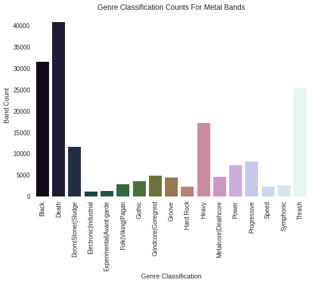

```python
sns.plt.title('Genre Classification Counts For Metal Bands') # Set graph title
genre_plot = sns.barplot(x = list(range(0,len(genre_total_df))),
                 y = genre_total_df['band count'],
                 palette = sns.color_palette("cubehelix", len(genre_total_df)))

genre_plot.set(xlabel = 'Genre Classification',
       ylabel = 'Band Count',
       xticklabels = list(genre_total_df.index)) # Set x-axis labels since python can't plot strings as values

sns.plt.xticks(rotation = 90) # Makes x-axis labels vertical
genre_plot.set_facecolor('white') # Changes tthe background to white
plt.show()
```

### Country Genre Counts

So we know the top overall metals genres, but let's look at what genres dominate each country. Instead of using `.value_counts()` let's use [**pivot_table**](https://pandas.pydata.org/pandas-docs/stable/generated/pandas.pivot_table.html) from `Pandas`. The `pivot_table` allows us to tally the bands with a genre type in a specific country.

```python
genre_by_country = pd.pivot_table(data = genre_data,
                                  index = ['country', 'CID'], # Combines all rows with the same values for these columns
                                  values = genre_regex_str, # Give pandas the columns you want the aggregate function to apply
                                  aggfunc = np.sum) # Specify what type of function, default is

genre_by_country.head()
```

| country | CID | Black | Death | Doom\|Stoner\|Sludge | Electronic\|Industrial | Experimental\|Avant-garde | Folk\|Viking\|Pagan | Gothic | Grindcore\|Goregrind | Groove | Hard Rock | Heavy | Metalcore\|Deathcore | Power | Progressive | Speed | Symphonic | Thrash |
| --- | --- | --- | --- | --- | --- | --- | --- | --- | --- | --- | --- | --- | --- | --- | --- | --- | --- | --- |
| Afghanistan | AF | 0.0 | 0.0 | 0.0 | 0.0 | 0.0 | 0.0 | 0.0 | 0.0 | 1.0 | 0.0 | 0.0 | 0.0 | 0.0 | 1.0 | 0.0 | 0.0 | 0.0 |
| Albania | AL | 3.0 | 4.0 | 0.0 | 0.0 | 0.0 | 1.0 | 0.0 | 0.0 | 1.0 | 1.0 | 3.0 | 0.0 | 1.0 | 1.0 | 1.0 | 0.0 | 2.0 |
| Algeria | DZ | 12.0 | 7.0 | 2.0 | 0.0 | 0.0 | 2.0 | 0.0 | 2.0 | 1.0 | 1.0 | 1.0 | 0.0 | 0.0 | 1.0 | 0.0 | 0.0 | 1.0 |
| Andorra | AD | 0.0 | 2.0 | 1.0 | 0.0 | 0.0 | 0.0 | 0.0 | 1.0 | 0.0 | 0.0 | 0.0 | 0.0 | 1.0 | 2.0 | 0.0 | 0.0 | 0.0 |
| Angola | AO | 1.0 | 0.0 | 0.0 | 0.0 | 0.0 | 0.0 | 0.0 | 0.0 | 0.0 | 0.0 | 1.0 | 1.0 | 0.0 | 0.0 | 0.0 | 0.0 | 1.0 |

# Genre by Country Plots

Let's plot the `DataFrame` from above to see the results. Since I'll be plotting 17 genre plots, let's make it a function so that we don't have to repeat code 17 times.

```python
def genre_bargraph(df, title, ylabel, genre, palette):
    plt.figure(figsize = (26,3)) # Change size of plot in inches
    sns.plt.title(title)
    ax = sns.barplot(x = list(df.index.labels[0]),
                     y = df[genre],
                     palette = palette)

    ax.set(xlabel = 'Country',
           ylabel = ylabel,
           xticklabels = list(df.index.levels[0]))

    sns.plt.xticks(rotation = 90)
    ax.set_facecolor('white')
```

**15/17** plots shows that the **United States** has a lot of bands in all 17 genres. However this doesn not help us answer the question of what genres dominate each country. So we have to take the band counts and divide by the total number of bands in that country.

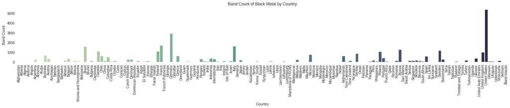

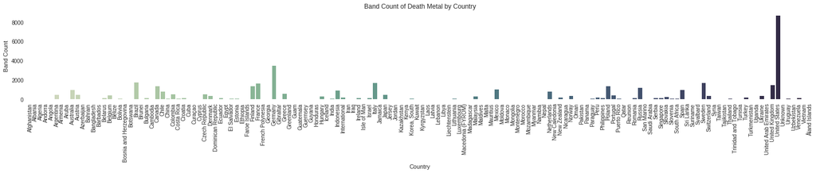

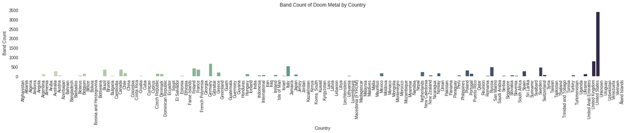

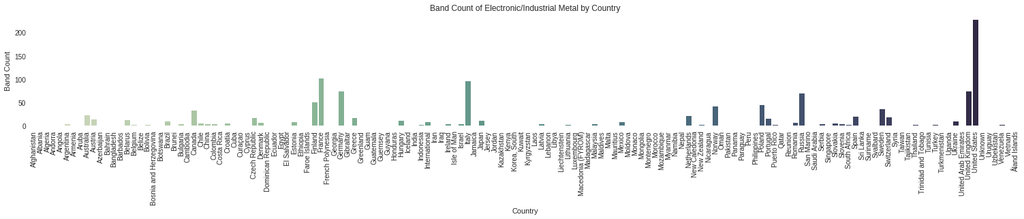

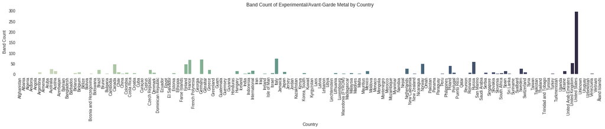

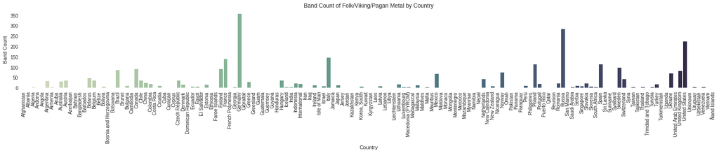

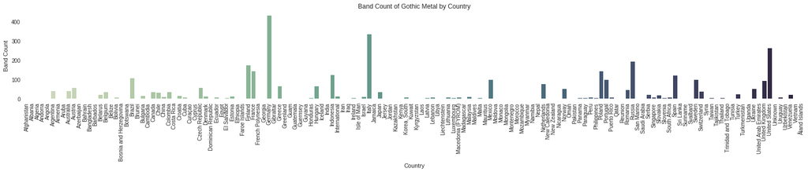

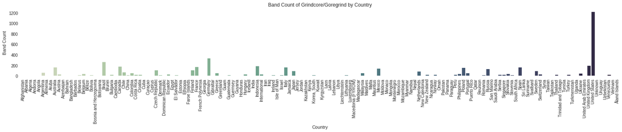

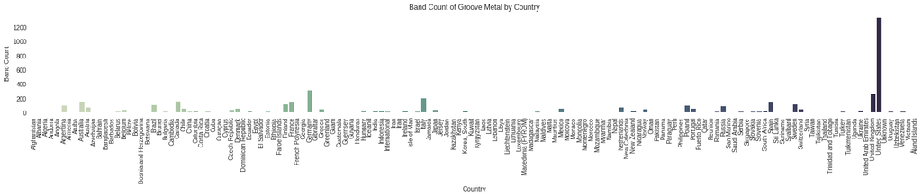

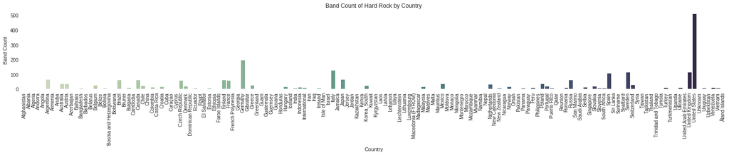

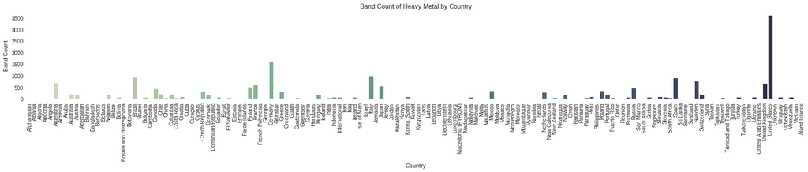

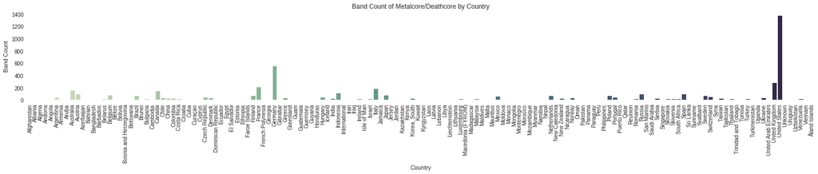

[5 more figures not shown]

```python
genre_lst = list(genre_by_country.columns)
l = len(genre_by_country)

titles = ['Black Metal','Death Metal','Doom Metal','Electronic/Industrial Metal',
          'Experimental/Avant-Garde Metal','Folk/Viking/Pagan Metal','Gothic Metal',
          'Grindcore/Goregrind','Groove Metal','Hard Rock','Heavy Metal','Metalcore/Deathcore',
          'Power Metal','Progressive Metal','Speed Metal','Symphonic Metal','Thrash Metal']

for idx in range(len(genre_lst)):
    genre_bargraph(genre_by_country,
                   'Band Count of ' + titles[idx] + ' by Country',
                   'Band Count',
                   genre_lst[idx],
                   sns.cubehelix_palette(l, start = 0.5, rot = -0.75))

plt.show()
```

First We need to calculate how many bands are in each country.

```python
band_count = pd.DataFrame(metal_data['country'].value_counts())
band_count = band_count.sort_index()
band_count.columns = ['band count']
band_count.head()
```

|  | band count |
| --- | --- |
| Afghanistan | 1 |
| Albania | 11 |
| Algeria | 23 |
| Andorra | 4 |
| Angola | 4 |

Now we can insert that into our original `DataFrame` and let's use [**NumPy**](http://www.numpy.org) to our advantage to calculate genre percentage. If you have two `NumPy` arrays of the same length, you can directly use:

```
a = np.array(dataA, dtype = np.float)
b = np.array(dataB, dtype = np.float)
list(a / b)
```

We do this for every genre and we're done!

```python
genre_percentage_by_country = genre_by_country.copy(deep = True)
genre_percentage_by_country.insert(0, 'band count', list(band_count['band count'])) # Insert total band counts into DataFrame
lst = list(genre_percentage_by_country.columns)[1:]
for idx in range(len(lst)):
    curr_genre = genre_percentage_by_country[lst[idx]]
    genre_arr = np.array(curr_genre, dtype = np.float)
    total_arr = np.array(genre_percentage_by_country['band count'], dtype = np.float)
    genre_percentage_by_country[lst[idx]] = list(genre_arr / total_arr)

genre_percentage_by_country.head()
```

| country | CID | band count | Black | Death | Doom\|Stoner\|Sludge | Electronic\|Industrial | Experimental\|Avant-garde | Folk\|Viking\|Pagan | Gothic | Grindcore\|Goregrind | Groove | Hard Rock | Heavy | Metalcore\|Deathcore | Power | Progressive | Speed | Symphonic | Thrash |
| --- | --- | --- | --- | --- | --- | --- | --- | --- | --- | --- | --- | --- | --- | --- | --- | --- | --- | --- | --- |
| Afghanistan | AF | 1 | 0.000000 | 0.000000 | 0.000000 | 0.0 | 0.0 | 0.000000 | 0.0 | 0.000000 | 1.000000 | 0.000000 | 0.000000 | 0.00 | 0.000000 | 1.000000 | 0.000000 | 0.0 | 0.000000 |
| Albania | AL | 11 | 0.272727 | 0.363636 | 0.000000 | 0.0 | 0.0 | 0.090909 | 0.0 | 0.000000 | 0.090909 | 0.090909 | 0.272727 | 0.00 | 0.090909 | 0.090909 | 0.090909 | 0.0 | 0.181818 |
| Algeria | DZ | 23 | 0.521739 | 0.304348 | 0.086957 | 0.0 | 0.0 | 0.086957 | 0.0 | 0.086957 | 0.043478 | 0.043478 | 0.043478 | 0.00 | 0.000000 | 0.043478 | 0.000000 | 0.0 | 0.043478 |
| Andorra | AD | 4 | 0.000000 | 0.500000 | 0.250000 | 0.0 | 0.0 | 0.000000 | 0.0 | 0.250000 | 0.000000 | 0.000000 | 0.000000 | 0.00 | 0.250000 | 0.500000 | 0.000000 | 0.0 | 0.000000 |
| Angola | AO | 4 | 0.250000 | 0.000000 | 0.000000 | 0.0 | 0.0 | 0.000000 | 0.0 | 0.000000 | 0.000000 | 0.000000 | 0.250000 | 0.25 | 0.000000 | 0.000000 | 0.000000 | 0.0 | 0.250000 |

Let's regraph you can see for each country what genres are really prevalent in each country.

#### [ANSWER TO Q1B]: Which genre type seems to dominate the metal playing field in every country?

The answer is actually all of our 17 graphs! Let's look at one as an example:

[figure not shown]

If the bars for that country is high, then this type of genre is a very popular genre for this specific country.

*You can double click on the graphs to enlarge them.

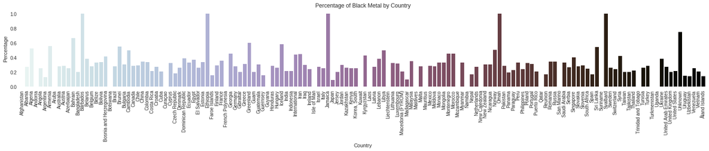

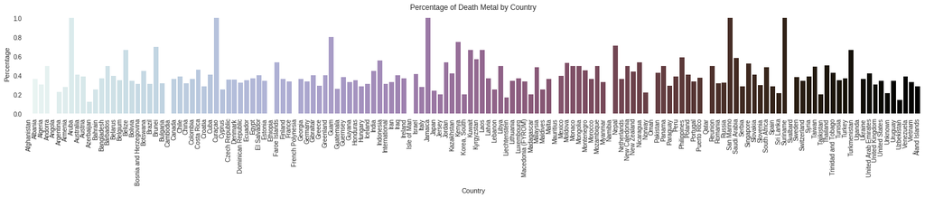

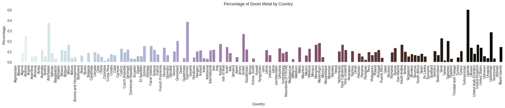

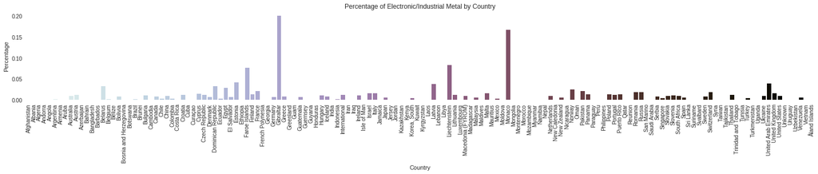

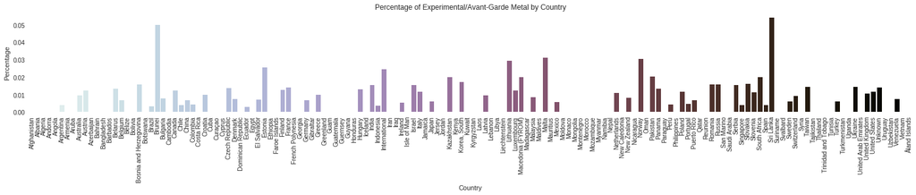

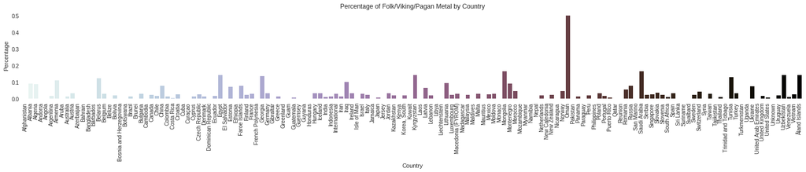

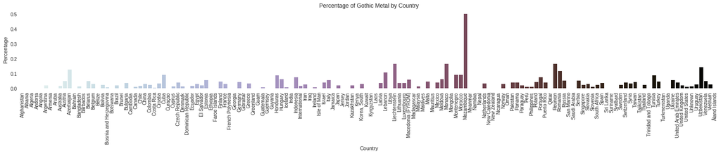

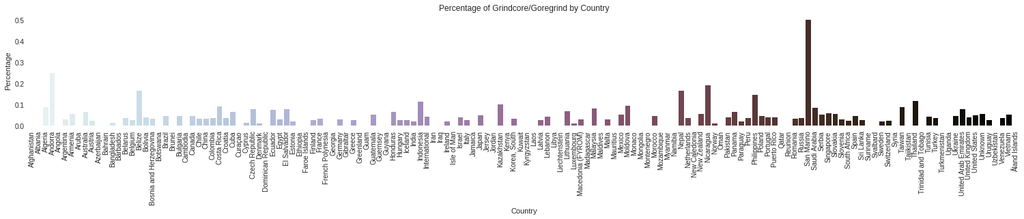

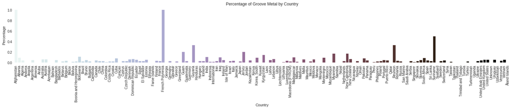

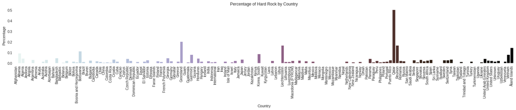

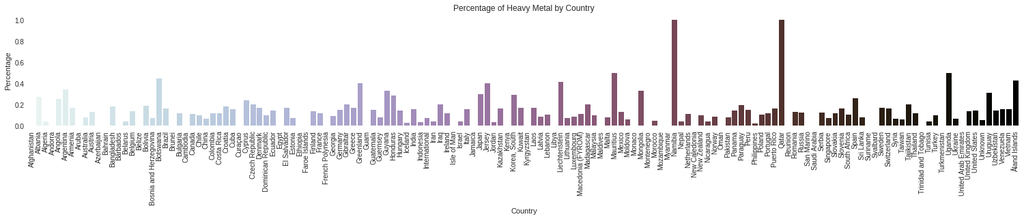

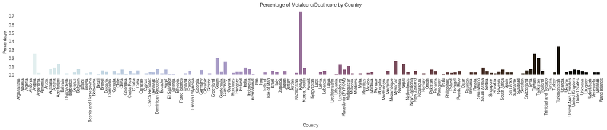

[5 more figures not shown]

```python
genre_lst = list(genre_percentage_by_country.columns)[1:]
l = len(genre_percentage_by_country)
for idx in range(len(genre_lst)):
    genre_bargraph(genre_percentage_by_country,
                   'Percentage of ' + titles[idx] + ' by Country',
                   'Percentage',
                   genre_lst[idx],
                   sns.cubehelix_palette(l, start = 1.5, rot = -0.75, dark = 0, light = 0.95))

plt.show()
```

#### [ANSWER TO Q1C]: Are most genres mixed or pure?

Looking at the graph we made more than **70,000** bands are pure one type of genre while around **40,000** bands are mix of 2 different genre types. Around 61% are pure and 34% are mix of 2, and around 40% are a mix of 2 or more genre types. I'm actually surprised since most bands are usually listed with so many genre tags.

```python
purity_counts = pd.DataFrame(genre_purity_data['genre groups'].value_counts())
purity_counts
```

|  | genre groups |
| --- | --- |
| 1 | 72692 |
| 2 | 40039 |
| 3 | 5662 |
| 0 | 678 |
| 4 | 384 |
| 5 | 18 |
| 6 | 1 |

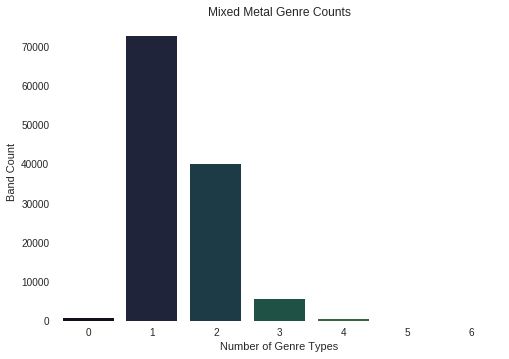

```python
sns.plt.title('Mixed Metal Genre Counts') # Set graph title
genre_plot = sns.barplot(x = list(purity_counts.index),
                         y = purity_counts['genre groups'],
                         palette = sns.color_palette("cubehelix", len(purity_counts) * 2))

genre_plot.set(xlabel = 'Number of Genre Types', ylabel = 'Band Count') # Set x-axis and y-axis label names

genre_plot.set_facecolor('white') # Changes tthe background to white
plt.show()
```

## Top Metal Countries

### Answers Question #2:

- **Which country is the most metal?**
- Most metal bands in proportion to population
- Most still active metal bands in proportion to population
- Most split-up metal bands in proportion to population

Let's apply all of the python techiques to create a `DataFrame` for the status types for every country.

```python
c = list(band_count.index)
status_types = list(overall_status_counts.index)
status_count_data = {}
status_count_data['Total'] = list(band_count['band count'])
status_count_data['Active'] = []
status_count_data['Split-up'] = []
status_count_data['Changed name'] = []
status_count_data['On hold'] = []
status_count_data['Unknown'] = []
status_count_data['Disputed'] = []

for idx in range(len(c)):
    status_counts = metal_data[metal_data['country'] == c[idx]]['status'].value_counts()
    for st in range(len(status_types)):
        if status_types[st] in status_counts:
            status_count_data[status_types[st]].append(status_counts[status_types[st]])
        else:
            status_count_data[status_types[st]].append(0)

status_data = pd.DataFrame(data = status_count_data, index = c, columns = ['Total'] + status_types)
status_data.head()
```

|  | Total | Active | Split-up | Unknown | Changed name | On hold | Disputed |
| --- | --- | --- | --- | --- | --- | --- | --- |
| Afghanistan | 1 | 1 | 0 | 0 | 0 | 0 | 0 |
| Albania | 11 | 6 | 4 | 1 | 0 | 0 | 0 |
| Algeria | 23 | 10 | 10 | 2 | 0 | 1 | 0 |
| Andorra | 4 | 3 | 1 | 0 | 0 | 0 | 0 |
| Angola | 4 | 4 | 0 | 0 | 0 | 0 | 0 |

We need to insert the population data we scrapped earlier into the new `DataFrame`, we have to merge the two data sets together. Since there are some countries with different names in the data set, so I created an alias dictionary to solve the problem.

```python
alias = {'Korea, South': 'South Korea',
         'Macedonia (FYROM)': 'Republic of Macedonia',
         'Georgia': 'Georgia (country)',
         'Ireland': 'Republic of Ireland'}
pop_dataframe_countries = list(population_data.index)
countries = list(status_data.index)

population_info = []
for c in range(len(countries)):

    country = countries[c]
    if country in alias:
        country = alias[country]
    if country in pop_dataframe_countries:
        country_population = population_data.loc[country]['population']
        population_info.append(country_population)
    else:
        population_info.append(0)

status_data.insert(0, 'Population (2017)', population_info)
status_data = status_data[status_data['Population (2017)'] != 0] # Remove countries with no population match
status_data.head()
```

|  | Population (2017) | Total | Active | Split-up | Unknown | Changed name | On hold | Disputed |
| --- | --- | --- | --- | --- | --- | --- | --- | --- |
| Afghanistan | 29724323 | 1 | 1 | 0 | 0 | 0 | 0 | 0 |
| Albania | 2876591 | 11 | 6 | 4 | 1 | 0 | 0 | 0 |
| Algeria | 41697498 | 23 | 10 | 10 | 2 | 0 | 1 | 0 |
| Andorra | 78264 | 4 | 3 | 1 | 0 | 0 | 0 | 0 |
| Angola | 28359634 | 4 | 4 | 0 | 0 | 0 | 0 | 0 |

### Calculating Per Capita

I wanted to calculate 3 different per capitas, one for overall, one for currently active bands, and one for bands that have split-up. This will tell us which countries have the most metal music activity in proportion to population.

**The equation for calculating Per Capita (# of bands per person):**

$\text{Per Capita} = \dfrac{\text{band count}}{\text{population}} \times \text{(scalar)}$

The scalar let's you control the proportion, if you want the original definition of per capita, the scalar is 1 for each person in the population. I'm going to do per every ten thousand individuals so my scalar is 10,000.

```python
total_arr = np.array(list(status_data['Total']), dtype = np.float)
active_arr = np.array(list(status_data['Active']), dtype = np.float)
split_arr = np.array(list(status_data['Split-up']), dtype = np.float)
population_arr = np.array(list(status_data['Population (2017)']), dtype = np.float)

status_data.insert(2, 'Total Per Capita (10,000)', list((total_arr / population_arr) * 10000))
status_data.insert(4, 'Active Per Capita (10,000)', list((active_arr / population_arr) * 10000))
status_data.insert(6, 'Split-up Per Capita (10,000)', list((split_arr / population_arr) * 10000))
status_data.head()
```

|  | Population (2017) | Total | Total Per Capita (10,000) | Active | Active Per Capita (10,000) | Split-up | Split-up Per Capita (10,000) | Unknown | Changed name | On hold | Disputed |
| --- | --- | --- | --- | --- | --- | --- | --- | --- | --- | --- | --- |
| Afghanistan | 29724323 | 1 | 0.000336 | 1 | 0.000336 | 0 | 0.000000 | 0 | 0 | 0 | 0 |
| Albania | 2876591 | 11 | 0.038240 | 6 | 0.020858 | 4 | 0.013905 | 1 | 0 | 0 | 0 |
| Algeria | 41697498 | 23 | 0.005516 | 10 | 0.002398 | 10 | 0.002398 | 2 | 0 | 1 | 0 |
| Andorra | 78264 | 4 | 0.511091 | 3 | 0.383318 | 1 | 0.127773 | 0 | 0 | 0 | 0 |
| Angola | 28359634 | 4 | 0.001410 | 4 | 0.001410 | 0 | 0.000000 | 0 | 0 | 0 | 0 |

### Metal Choropleth Map

Here, we're going to use [**folium**](https://folium.readthedocs.io/en/latest/) make an **interactive choropleth map**, it'll let us see which country is the most metal better than a bar graph. I was inspired by this [Metal Injection Blog Post](http://www.metalinjection.net/around-the-interwebs/which-country-has-the-most-metal-bands-per-capita).

```
!pip install folium
import folium
```

The **GEOJSON** file of the world is located [here](https://github.com/datasets/geo-countries/tree/master/data)

It isn't exactly difficult if your data matches with the **GEOJSON** file exactly, but in our case, the file has information for a lot more countries than there are in the `DataFrame`. The subsequent 2 cells contain code that modify the `DataFrame` to include all the countries in the **GEOJSON** file and for countries that were not in our `DataFrame`, we have to give them filler values.

```python
choropleth_data = status_data.copy(deep = True)
alias = {'Serbia': 'Republic of Serbia',
         'Macedonia (FYROM)': 'Macedonia',
         'Korea, South': 'South Korea',
         'United States': 'United States of America'}

# Going through the JSON file to extract all the countries
with open('countries.geo.json', 'r') as country_boundaries_geojson:
    country_boundaries = json.load(country_boundaries_geojson)
    cb = [country_boundaries['features'][i]['properties']['ADMIN']for i in range(len(country_boundaries['features']))]
    country_boundaries_geojson.close()

l = list(choropleth_data.index)
geojson_country_name = []

# Making a column of the country name from the JSON file
# In order to make the map, all country names in DataFrame must
# Match the names in the JSON file.
for i in range(len(l)):
    if l[i] in alias:
        geojson_country_name.append(alias[l[i]])
    elif l[i] in cb:
        geojson_country_name.append(l[i])

choropleth_data.insert(0, 'geojson_country_name', geojson_country_name)
choropleth_data = choropleth_data.drop(['Unknown','Changed name','On hold','Disputed'], 1)
choropleth_data.head()
```

|  | geojson_country_name | Population (2017) | Total | Total Per Capita (10,000) | Active | Active Per Capita (10,000) | Split-up | Split-up Per Capita (10,000) |
| --- | --- | --- | --- | --- | --- | --- | --- | --- |
| Afghanistan | Afghanistan | 29724323 | 1 | 0.000336 | 1 | 0.000336 | 0 | 0.000000 |
| Albania | Albania | 2876591 | 11 | 0.038240 | 6 | 0.020858 | 4 | 0.013905 |
| Algeria | Algeria | 41697498 | 23 | 0.005516 | 10 | 0.002398 | 10 | 0.002398 |
| Andorra | Andorra | 78264 | 4 | 0.511091 | 3 | 0.383318 | 1 | 0.127773 |
| Angola | Angola | 28359634 | 4 | 0.001410 | 4 | 0.001410 | 0 | 0.000000 |

```python
# Collect all the countries not matched from the JSON file
no_match = [cb[c] for c in range(len(cb)) if cb[c] not in geojson_country_name]

# Creating a DataFrame for the non-matched countries
# and giving them filler values
filler = [-1] * (len(no_match))
filler_data = {}
choropleth_col = list(choropleth_data.columns)
for idx in range(len(choropleth_data.columns)):
    h = choropleth_col[idx]
    if h == 'country':
        filler_data[h] = [''] * (len(no_match))
    elif h == 'CID':
        filler_data[h] = ['--'] * (len(no_match))
    elif h == 'geojson_country_name':
        filler_data[h] = no_match
    else:
        filler_data[h] = filler

# Combine original DataFrame with non-match DataFrame
geojson_no_matches = pd.DataFrame(data = filler_data,columns = choropleth_col)
choropleth_data = choropleth_data.append(geojson_no_matches)
choropleth_data
```

|  | geojson_country_name | Population (2017) | Total | Total Per Capita (10,000) | Active | Active Per Capita (10,000) | Split-up | Split-up Per Capita (10,000) |
| --- | --- | --- | --- | --- | --- | --- | --- | --- |
| Afghanistan | Afghanistan | 29724323 | 1 | 0.000336 | 1 | 0.000336 | 0 | 0.000000 |
| Albania | Albania | 2876591 | 11 | 0.038240 | 6 | 0.020858 | 4 | 0.013905 |
| Algeria | Algeria | 41697498 | 23 | 0.005516 | 10 | 0.002398 | 10 | 0.002398 |
| Andorra | Andorra | 78264 | 4 | 0.511091 | 3 | 0.383318 | 1 | 0.127773 |
| Angola | Angola | 28359634 | 4 | 0.001410 | 4 | 0.001410 | 0 | 0.000000 |
| Argentina | Argentina | 44044811 | 2016 | 0.457716 | 1326 | 0.301057 | 481 | 0.109207 |
| Armenia | Armenia | 2979600 | 18 | 0.060411 | 14 | 0.046986 | 4 | 0.013425 |
| Aruba | Aruba | 110882 | 1 | 0.090186 | 0 | 0.000000 | 0 | 0.000000 |
| Australia | Australia | 24746700 | 2382 | 0.962553 | 1350 | 0.545527 | 717 | 0.289736 |
| Austria | Austria | 8817514 | 1125 | 1.275870 | 564 | 0.639636 | 407 | 0.461581 |
| Azerbaijan | Azerbaijan | 9867250 | 8 | 0.008108 | 6 | 0.006081 | 2 | 0.002027 |
| Bahrain | Bahrain | 1451200 | 12 | 0.082690 | 6 | 0.041345 | 6 | 0.041345 |
| Bangladesh | Bangladesh | 163646000 | 65 | 0.003972 | 56 | 0.003422 | 7 | 0.000428 |
| Barbados | Barbados | 285719 | 2 | 0.069999 | 2 | 0.069999 | 0 | 0.000000 |
| Belarus | Belarus | 9495800 | 375 | 0.394911 | 247 | 0.260115 | 90 | 0.094779 |
| Belgium | Belgium | 11385383 | 1196 | 1.050470 | 535 | 0.469901 | 546 | 0.479562 |
| Belize | Belize | 380010 | 6 | 0.157891 | 4 | 0.105260 | 1 | 0.026315 |
| Bolivia | Bolivia | 11145770 | 245 | 0.219814 | 181 | 0.162393 | 39 | 0.034991 |
| Bosnia and Herzegovina | Bosnia and Herzegovina | 3518000 | 126 | 0.358158 | 78 | 0.221717 | 34 | 0.096646 |
| Botswana | Botswana | 2230905 | 9 | 0.040342 | 8 | 0.035860 | 1 | 0.004482 |
| Brazil | Brazil | 208390000 | 5622 | 0.269783 | 3413 | 0.163779 | 1607 | 0.077115 |
| Brunei | Brunei | 417200 | 20 | 0.479386 | 9 | 0.215724 | 8 | 0.191755 |
| Bulgaria | Bulgaria | 7101859 | 381 | 0.536479 | 180 | 0.253455 | 170 | 0.239374 |
| Cambodia | Cambodia | 15848495 | 2 | 0.001262 | 2 | 0.001262 | 0 | 0.000000 |
| Canada | Canada | 36746700 | 3752 | 1.021044 | 2022 | 0.550253 | 1294 | 0.352140 |
| Chile | Chile | 17373831 | 1999 | 1.150581 | 1483 | 0.853583 | 333 | 0.191668 |
| China | China | 1388060000 | 300 | 0.002161 | 241 | 0.001736 | 43 | 0.000310 |
| Colombia | Colombia | 49538200 | 1432 | 0.289070 | 1111 | 0.224271 | 204 | 0.041180 |
| Costa Rica | Costa Rica | 4947490 | 217 | 0.438606 | 165 | 0.333502 | 32 | 0.064679 |
| Croatia | Croatia | 4154213 | 405 | 0.974914 | 204 | 0.491068 | 136 | 0.327378 |
| ... | ... | ... | ... | ... | ... | ... | ... | ... |
| 82 | Saint Helena | -1 | -1 | -1.000000 | -1 | -1.000000 | -1 | -1.000000 |
| 83 | Solomon Islands | -1 | -1 | -1.000000 | -1 | -1.000000 | -1 | -1.000000 |
| 84 | Sierra Leone | -1 | -1 | -1.000000 | -1 | -1.000000 | -1 | -1.000000 |
| 85 | Somaliland | -1 | -1 | -1.000000 | -1 | -1.000000 | -1 | -1.000000 |
| 86 | Somalia | -1 | -1 | -1.000000 | -1 | -1.000000 | -1 | -1.000000 |
| 87 | Saint Pierre and Miquelon | -1 | -1 | -1.000000 | -1 | -1.000000 | -1 | -1.000000 |
| 88 | Sao Tome and Principe | -1 | -1 | -1.000000 | -1 | -1.000000 | -1 | -1.000000 |
| 89 | Swaziland | -1 | -1 | -1.000000 | -1 | -1.000000 | -1 | -1.000000 |
| 90 | Sint Maarten | -1 | -1 | -1.000000 | -1 | -1.000000 | -1 | -1.000000 |
| 91 | Seychelles | -1 | -1 | -1.000000 | -1 | -1.000000 | -1 | -1.000000 |
| 92 | Turks and Caicos Islands | -1 | -1 | -1.000000 | -1 | -1.000000 | -1 | -1.000000 |
| 93 | Chad | -1 | -1 | -1.000000 | -1 | -1.000000 | -1 | -1.000000 |
| 94 | Togo | -1 | -1 | -1.000000 | -1 | -1.000000 | -1 | -1.000000 |
| 95 | East Timor | -1 | -1 | -1.000000 | -1 | -1.000000 | -1 | -1.000000 |
| 96 | Tonga | -1 | -1 | -1.000000 | -1 | -1.000000 | -1 | -1.000000 |
| 97 | Tuvalu | -1 | -1 | -1.000000 | -1 | -1.000000 | -1 | -1.000000 |
| 98 | United Republic of Tanzania | -1 | -1 | -1.000000 | -1 | -1.000000 | -1 | -1.000000 |
| 99 | United States Minor Outlying Islands | -1 | -1 | -1.000000 | -1 | -1.000000 | -1 | -1.000000 |
| 100 | US Naval Base Guantanamo Bay | -1 | -1 | -1.000000 | -1 | -1.000000 | -1 | -1.000000 |
| 101 | Vatican | -1 | -1 | -1.000000 | -1 | -1.000000 | -1 | -1.000000 |
| 102 | Saint Vincent and the Grenadines | -1 | -1 | -1.000000 | -1 | -1.000000 | -1 | -1.000000 |
| 103 | British Virgin Islands | -1 | -1 | -1.000000 | -1 | -1.000000 | -1 | -1.000000 |
| 104 | United States Virgin Islands | -1 | -1 | -1.000000 | -1 | -1.000000 | -1 | -1.000000 |
| 105 | Vanuatu | -1 | -1 | -1.000000 | -1 | -1.000000 | -1 | -1.000000 |
| 106 | Wallis and Futuna | -1 | -1 | -1.000000 | -1 | -1.000000 | -1 | -1.000000 |
| 107 | Akrotiri Sovereign Base Area | -1 | -1 | -1.000000 | -1 | -1.000000 | -1 | -1.000000 |
| 108 | Samoa | -1 | -1 | -1.000000 | -1 | -1.000000 | -1 | -1.000000 |
| 109 | Yemen | -1 | -1 | -1.000000 | -1 | -1.000000 | -1 | -1.000000 |
| 110 | Zambia | -1 | -1 | -1.000000 | -1 | -1.000000 | -1 | -1.000000 |
| 111 | Zimbabwe | -1 | -1 | -1.000000 | -1 | -1.000000 | -1 | -1.000000 |

255 rows × 8 columns

`folium` has a built in `choropleth` function. Because I have to graph 3 of them, I made a function and I had them all added in as layers. Because the map is so tasking on the computer, saving it as an html file is a good option if your computer can't handle the large amount of graphics.

View the full map by downloading it [here](https://github.com/yjlo/metal_music_project/blob/master/metalband_choropleth_map.zip)

With the map layers, we answer our 2nd question.

#### [ANSWER TO Q2A-C]: Which country is the most metal?

**Finland** and those Scandinavians! Finland is the top for all 3 maps and that shows that metal music activity in Finland is extremely high even though they are not the one of the most population dense countries in the world.

Here are some resources for choropleth maps:

1. [Color Brewer](http://colorbrewer2.org/#type=sequential&scheme=BuGn&n=3)
2. [Quickstart Example Code](http://folium.readthedocs.io/en/latest/quickstart.html)
3. [Folium Documentation](http://webcache.googleusercontent.com/search?q=cache:vFIv6ObzPG4J:python-visualization.github.io/folium/docs-master/modules.html+&cd=4&hl=en&ct=clnk&gl=us)

```python
# Function to add choropleth overlay to base map
def build_choropleth(base_map, name, field, threshold, color):
    base_map.choropleth(name = name + 'Metal Bands Per Capita (10,000)',
                geo_data = 'countries.geo.json', # JSON file containing the country boundary lines
                data = choropleth_data, # DataFrame to plot from
                columns = ['geojson_country_name', field + ' Per Capita (10,000)'], # Which columns to plot
                key_on = 'feature.properties.ADMIN', # What property in the JSON file to match the column data with
                threshold_scale = threshold, # Adjusts legend color scale
                fill_color = color, fill_opacity = 0.5, line_opacity = 0.5, # Choropleth color overlay options
                legend_name = name + 'Metal Bands Per Capita (10,000)',
                reset = True, highlight = True)

base_map = folium.Map(location = [0,0], zoom_start = 1.5)
build_choropleth(base_map, '', 'Total', [0,1,2,5,6,7], 'BuPu')
build_choropleth(base_map, 'Active', 'Active', [-1,0,1,2,3,4], 'BuGn')
build_choropleth(base_map, 'Split-up', 'Split-up', [-1.0, -0.1, 0.4, 0.9, 1.4, 1.9], 'YlOrRd')

folium.LayerControl().add_to(base_map)
base_map.save('metalband_choropleth_map.html') # Save as html because most computers can't handle the loading the map
```

# Conculsion & Major Souces

If you have stuck with me till the end, then congratulations! We did some incredible things in Python 3 and answered these metal music questions:

1. **Which genre type seems to dominate the metal playing field?**
   - For the metal genre in general
   - For each country
   - Are most genres mixed or pure?
2. **Which country is the most metal?**
   - Most metal bands in proportion to population
   - Most still active metal bands in proportion to population
   - Most split-up metal bands in proportion to population

In comparison with the [kaggle notebook](https://www.kaggle.com/mrpantherson/metal-by-nation-and-genre/notebook), we had pretty similar results even though the data set here is 20 times larger. Our most metal country was Finland, but for the kaggle analysis it was the Faroes Islands, which is actually an island off of the Scandinavian paninsulas. A lot of the genre analysis was similar as well.

Thanks for reading and following along!

## Sources

- **Data Sources**
  - [Encyclopedia Metallum](http://metal-archives.com)
  - [Wikipedia Population Data](https://en.wikipedia.org/wiki/List_of_countries_and_dependencies_by_population)
  - [World GEOJSON](https://github.com/datasets/geo-countries/tree/master/data)
- **Inpiration/Reference Sources**
  - [Kaggle's Metal by Nation and Genre](https://www.kaggle.com/mrpantherson/metal-by-nation)
  - [Kaggle Notebook](https://www.kaggle.com/mrpantherson/metal-by-nation-and-genre/notebook)
  - [Map of Metal](https://mapofmetal.com/)
  - [GitHub: jonchar's Metal Archives Scarper](https://github.com/jonchar/ma-scraper)

## \m/ ( -*- ) \m/ BACK TO TOP \m/ ( -*- ) \m/